# Part II - (VISUAL EXPLORATION OF LOAN DATA DATASET)

## by (Robert Kipchumba Korir)

## Investigation Overview

The major goals of this presentation is to convey the distribution of various important variables in the dataset such as`StateMonthlyIncome`,`BorrowerAPR` and `BorrowerRate`. It also hopes to convey the relationship between loan amounts borrowed, with EmploymentStatus as well as Homeowner status

> Some of the key insights from the dataset are as follows

> The `BorrowerAPR` and `BorrowerRate` are strongly related and follow a similar distribution. `StatedMonthlyIncome`'s distribution is normal and therefore unimodal. Employed people are seen to ask for loans the most. This applies to homeowners as well as they appear to borrow more loans compared to non homeowners

## Dataset Overview

> The dataset tied to the investigation contains Loan Data information from the year 2005 to 2014. It contains around 87 variables

## Visualization 1:

### How is the distribution of Monthly income for borrowers?

The plot below shows the distribution of the variable `StatedMonthlyIncome`. The distribution of this variable is normal, evidenced by the histogram's unimodal appearance. The peak of the monthly incomes comes at around the 4000 dollar mark

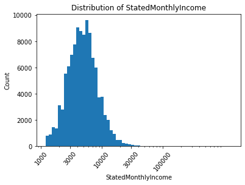

## Visualization 2:

### How does Homeownership and Employment status affect The loan amounts borrowed?

> The plot below represents the Loan amounts borrowed by different people of different employment statuses, grouped by whether or not they have a home. From the plot, we can deduce the fact that employed people are seen to ask for loans the most. This applies to homeowners as well as they appear to borrow more loans compared to non homeowners

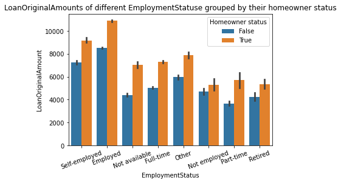

## Visualization 3

### What is the relationship between APR, Interest Rate against the loan amount borrowed

> The plot below shows the InterestRate and `BorrowerAPR` against the origninal amount borrowed. From the plot we can deduce that `BorrowerRate` and `BorrowerAPR` are strongly linked and have similar distribution against the `LoanOriginalAmount`. The heatmap shows that alot of the loans fall between amounts 0 and 15000, with the most values falling where the interest rates and APR is around 0.3 and 0.3-0.4 respectively

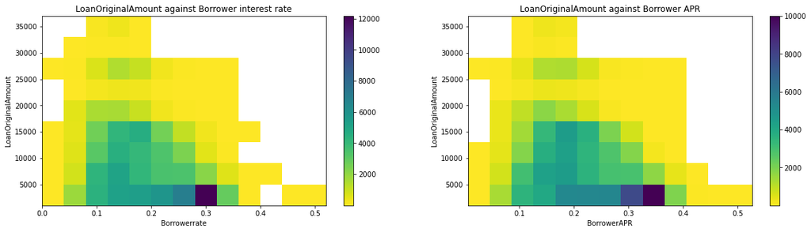